# Project 4

Tobechi Dimkpa

February 17 2025

# Depression study analysis

This study had two active treatments and a control group over 10 weeks. The main outcome of interest was the PHQ-9 sum score, which can range from 0-27. The data is stored in the `depression_study.csv` file.

### a)

Important things to notice:* (1) Your colleague is interested in mean PHQ-9 by treatment by day. (2) Your colleague wants the x and y axis to have specific ranges, tick marks, and labels. (3) Your colleague wants the colors of the three treatments to be different. (4) Your colleague wants the points that represent the three treatments to be different as well – squares, circles, and triangles. (5) Your colleague wants the legend below the plot.

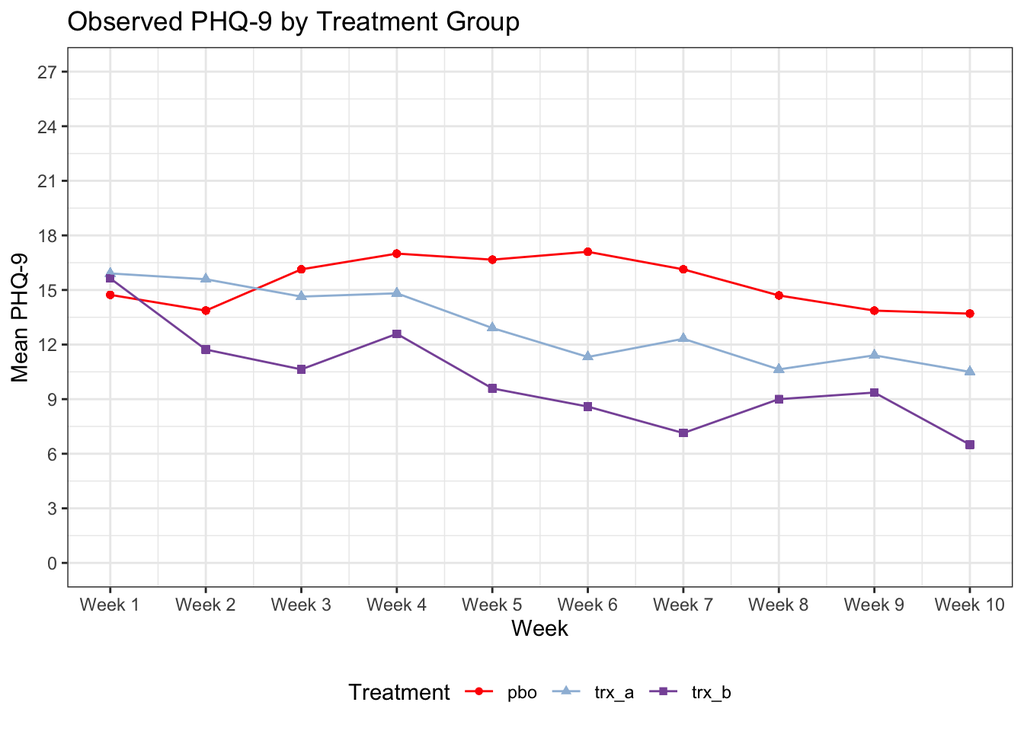

```r
#Read in the dataset
depression_study <- read_csv("data/depression_study.csv")

#Create mean by treatment
depression <- depression_study %>%
  group_by(treatment, week) %>%
  mutate(mean_phq9 = mean(phq9))

#Create the plot
ggplot(depression, aes(x = week, y = mean_phq9, color= treatment, shape = treatment, group = treatment)) +
  geom_point() +
  geom_line() +   # Lines to connect the points
  scale_x_continuous(breaks = seq(1, 10, by = 1), labels = paste0("Week ", seq(1, 10, by = 1))) +  # Custom X-axis labels
  scale_y_continuous(breaks = seq(0, 27, by = 3), limits = c(0, 27)) +  # Custom Y-axis
  scale_color_manual(values = c("red", "#9ebcda", "#8856a7")) +  # Different colors for treatments
  theme_bw() +
  theme(legend.position = "bottom") + # Move legend to bottom
  guides(color = guide_legend(title = "Treatment"),  shape = guide_legend(title = "Treatment"))+ # Ensures color and shape are in one legend
  labs(title = "Observed PHQ-9 by Treatment Group", x = "Week", y = "Mean PHQ-9", color = "Treatment")
```

# Biometrics data analysis

### a)

Use the `tbl_summary()` function from the `gtsummary` package to create a descriptive table summarizing all the **girth** measurements from the biometrics dataset (`biometrics.xls`).

```r
biometrics_raw <- read_xls("data/biometrics.xls", sheet = 2)

biometrics <- biometrics_raw %>%
  select(contains("girth"))  %>%
  tbl_summary(statistic = list(all_continuous() ~ "{mean} ({sd}) | Min: {min} | Median: {median} | Max: {max}"),
  label = list(
      shoulder_girth ~ "Shoulder Girth",
      chest_girth ~ "Chest Girth",
      waist_girth ~ "Waist Girth",
      navel_girth ~ "Navel Girth",
      hip_girth ~ "Hip Girth",
      thigh_girth ~ "Thigh Girth",
      bicep_girth_flexed ~ "Bicep Girth (Flexed)",
      forearm_girth ~ "Forearm Girth",
      knee_girth ~ "Knee Girth",
      calf_girth ~ "Calf Girth",
      ankle_girth ~ "Ankle Girth",
      wrist_girth ~ "Wrist Girth"
    ))
print(biometrics)
```

| **Characteristic** | **N = 507**<sup>1</sup> |
| --- | --- |
| Shoulder Girth | 108 (10) \| Min: 86 \| Median: 108 \| Max: 135 |
| Chest Girth | 93 (10) \| Min: 73 \| Median: 92 \| Max: 119 |
| Waist Girth | 77 (11) \| Min: 58 \| Median: 76 \| Max: 113 |
| Navel Girth | 86 (9) \| Min: 64 \| Median: 85 \| Max: 121 |
| Hip Girth | 97 (7) \| Min: 79 \| Median: 96 \| Max: 128 |
| Thigh Girth | 56.9 (4.5) \| Min: 46.3 \| Median: 56.3 \| Max: 75.7 |
| Bicep Girth (Flexed) | 31.2 (4.2) \| Min: 22.4 \| Median: 31.0 \| Max: 42.4 |
| Forearm Girth | 25.94 (2.83) \| Min: 19.60 \| Median: 25.80 \| Max: 32.50 |
| Knee Girth | 36.20 (2.62) \| Min: 29.00 \| Median: 36.00 \| Max: 49.00 |
| Calf Girth | 36.08 (2.85) \| Min: 28.40 \| Median: 36.00 \| Max: 47.70 |
| Ankle Girth | 22.16 (1.86) \| Min: 16.40 \| Median: 22.00 \| Max: 29.30 |
| Wrist Girth | 16.10 (1.38) \| Min: 13.00 \| Median: 16.10 \| Max: 19.60 |

<sup>1</sup> Mean (SD) | Min: Min | Median: Median | Max: Max

### b)

Split descriptive table from above by gender.

```r
biometrics <- biometrics_raw %>%
  select(gender, contains("girth"))  %>%
  tbl_summary(by = gender,
    statistic = list(all_continuous() ~ "{mean} ({sd}) | Min: {min} | Median: {median} | Max: {max}"),
  label = list(
      shoulder_girth ~ "Shoulder Girth",
      chest_girth ~ "Chest Girth",
      waist_girth ~ "Waist Girth",
      navel_girth ~ "Navel Girth",
      hip_girth ~ "Hip Girth",
      thigh_girth ~ "Thigh Girth",
      bicep_girth_flexed ~ "Bicep Girth (Flexed)",
      forearm_girth ~ "Forearm Girth",
      knee_girth ~ "Knee Girth",
      calf_girth ~ "Calf Girth",
      ankle_girth ~ "Ankle Girth",
      wrist_girth ~ "Wrist Girth"
    ))
print(biometrics)
```

| **Characteristic** | **Female** N = 260<sup>1</sup> | **Male** N = 247<sup>1</sup> |
| --- | --- | --- |
| Shoulder Girth | 100 (6) \| Min: 86 \| Median: 100 \| Max: 130 | 117 (6) \| Min: 100 \| Median: 117 \| Max: 135 |
| Chest Girth | 86 (6) \| Min: 73 \| Median: 86 \| Max: 109 | 101 (7) \| Min: 79 \| Median: 101 \| Max: 119 |
| Waist Girth | 70 (8) \| Min: 58 \| Median: 68 \| Max: 102 | 85 (9) \| Min: 67 \| Median: 83 \| Max: 113 |
| Navel Girth | 84 (10) \| Min: 64 \| Median: 82 \| Max: 121 | 88 (8) \| Min: 67 \| Median: 87 \| Max: 112 |
| Hip Girth | 96 (7) \| Min: 79 \| Median: 95 \| Max: 128 | 98 (6) \| Min: 82 \| Median: 97 \| Max: 119 |
| Thigh Girth | 57.2 (4.6) \| Min: 46.3 \| Median: 56.4 \| Max: 75.7 | 56.5 (4.2) \| Min: 46.8 \| Median: 56.0 \| Max: 70.0 |
| Bicep Girth (Flexed) | 28.1 (2.7) \| Min: 22.4 \| Median: 27.8 \| Max: 40.3 | 34.4 (3.0) \| Min: 25.6 \| Median: 34.4 \| Max: 42.4 |
| Forearm Girth | 23.76 (1.68) \| Min: 19.60 \| Median: 23.60 \| Max: 30.80 | 28.24 (1.78) \| Min: 22.70 \| Median: 28.40 \| Max: 32.50 |
| Knee Girth | 35.26 (2.58) \| Min: 29.00 \| Median: 35.00 \| Max: 49.00 | 37.20 (2.27) \| Min: 31.10 \| Median: 37.00 \| Max: 45.70 |
| Calf Girth | 35.01 (2.61) \| Min: 28.40 \| Median: 34.85 \| Max: 45.40 | 37.21 (2.65) \| Min: 28.90 \| Median: 37.30 \| Max: 47.70 |
| Ankle Girth | 21.21 (1.44) \| Min: 17.40 \| Median: 21.10 \| Max: 26.00 | 23.16 (1.73) \| Min: 16.40 \| Median: 23.00 \| Max: 29.30 |
| Wrist Girth | 15.06 (0.85) \| Min: 13.00 \| Median: 15.00 \| Max: 18.20 | 17.19 (0.91) \| Min: 14.60 \| Median: 17.10 \| Max: 19.60 |

<sup>1</sup> Mean (SD) | Min: Min | Median: Median | Max: Max

### c)

Test for mean differences by gender using t-tests that assume equal variances.

```r
biometrics <- biometrics_raw %>%
  select(gender, contains("girth"))  %>%
  tbl_summary(by = gender,
    statistic = list(all_continuous() ~ "{mean} ({sd}) | Min: {min} | Median: {median} | Max: {max}"),
  label = list(
      shoulder_girth ~ "Shoulder Girth",
      chest_girth ~ "Chest Girth",
      waist_girth ~ "Waist Girth",
      navel_girth ~ "Navel Girth",
      hip_girth ~ "Hip Girth",
      thigh_girth ~ "Thigh Girth",
      bicep_girth_flexed ~ "Bicep Girth (Flexed)",
      forearm_girth ~ "Forearm Girth",
      knee_girth ~ "Knee Girth",
      calf_girth ~ "Calf Girth",
      ankle_girth ~ "Ankle Girth",
      wrist_girth ~ "Wrist Girth"
    )) %>%

add_p(test = all_continuous()~"t.test",
      test.args = all_tests("t.test") ~ list(var.equal= TRUE)) #Add column to test for mean differences assuming equal variance

print(biometrics)
```

| **Characteristic** | **Female** N = 260<sup>1</sup> | **Male** N = 247<sup>1</sup> | **p-value**<sup>2</sup> |
| --- | --- | --- | --- |
| Shoulder Girth | 100 (6) \| Min: 86 \| Median: 100 \| Max: 130 | 117 (6) \| Min: 100 \| Median: 117 \| Max: 135 | <0.001 |
| Chest Girth | 86 (6) \| Min: 73 \| Median: 86 \| Max: 109 | 101 (7) \| Min: 79 \| Median: 101 \| Max: 119 | <0.001 |
| Waist Girth | 70 (8) \| Min: 58 \| Median: 68 \| Max: 102 | 85 (9) \| Min: 67 \| Median: 83 \| Max: 113 | <0.001 |
| Navel Girth | 84 (10) \| Min: 64 \| Median: 82 \| Max: 121 | 88 (8) \| Min: 67 \| Median: 87 \| Max: 112 | <0.001 |
| Hip Girth | 96 (7) \| Min: 79 \| Median: 95 \| Max: 128 | 98 (6) \| Min: 82 \| Median: 97 \| Max: 119 | <0.001 |
| Thigh Girth | 57.2 (4.6) \| Min: 46.3 \| Median: 56.4 \| Max: 75.7 | 56.5 (4.2) \| Min: 46.8 \| Median: 56.0 \| Max: 70.0 | 0.078 |
| Bicep Girth (Flexed) | 28.1 (2.7) \| Min: 22.4 \| Median: 27.8 \| Max: 40.3 | 34.4 (3.0) \| Min: 25.6 \| Median: 34.4 \| Max: 42.4 | <0.001 |
| Forearm Girth | 23.76 (1.68) \| Min: 19.60 \| Median: 23.60 \| Max: 30.80 | 28.24 (1.78) \| Min: 22.70 \| Median: 28.40 \| Max: 32.50 | <0.001 |
| Knee Girth | 35.26 (2.58) \| Min: 29.00 \| Median: 35.00 \| Max: 49.00 | 37.20 (2.27) \| Min: 31.10 \| Median: 37.00 \| Max: 45.70 | <0.001 |
| Calf Girth | 35.01 (2.61) \| Min: 28.40 \| Median: 34.85 \| Max: 45.40 | 37.21 (2.65) \| Min: 28.90 \| Median: 37.30 \| Max: 47.70 | <0.001 |
| Ankle Girth | 21.21 (1.44) \| Min: 17.40 \| Median: 21.10 \| Max: 26.00 | 23.16 (1.73) \| Min: 16.40 \| Median: 23.00 \| Max: 29.30 | <0.001 |
| Wrist Girth | 15.06 (0.85) \| Min: 13.00 \| Median: 15.00 \| Max: 18.20 | 17.19 (0.91) \| Min: 14.60 \| Median: 17.10 \| Max: 19.60 | <0.001 |

<sup>1</sup> Mean (SD) | Min: Min | Median: Median | Max: Max  
<sup>2</sup> Two Sample t-test

### d)

Shoulder girth, chest girth, waist girth, navel girth, hip girth, bicep girth (flexed), forearm girth, knee girth, calf girth, ankle girth, and wrist girth were all significantly different between the genders (p < 0.001 for all).